# WK9

KVP

2/25/2021

## Data to dataframes

```r
list2env(tuesdata,globalenv())
```

```
## <environment: R_GlobalEnv>
```

```r
rm(tuesdata)

head(earn)
```

```
## # A tibble: 6 x 8
##   sex     race   ethnic_origin age       year quarter n_persons median_weekly_e…
##   <chr>   <chr>  <chr>         <chr>    <dbl>   <dbl>     <dbl>            <dbl>
## 1 Both S… All R… All Origins   16 year…  2010       1  96821000              754
## 2 Both S… All R… All Origins   16 year…  2010       2  99798000              740
## 3 Both S… All R… All Origins   16 year…  2010       3 101385000              740
## 4 Both S… All R… All Origins   16 year…  2010       4 100120000              752
## 5 Both S… All R… All Origins   16 year…  2011       1  98329000              755
## 6 Both S… All R… All Origins   16 year…  2011       2 100593000              753
```

```r
head(employed)
```

```
## # A tibble: 6 x 7
##   industry major_occupation minor_occupation race_gender industry_total employ_n
##   <chr>    <chr>            <chr>            <chr>                <dbl>    <dbl>
## 1 Agricul… Management, pro… Management, bus… TOTAL              2349000   961000
## 2 Agricul… Management, pro… Professional an… TOTAL              2349000    58000
## 3 Agricul… Service occupat… Protective serv… TOTAL              2349000    13000
## 4 Agricul… Service occupat… Service occupat… TOTAL              2349000    94000
## 5 Agricul… Sales and offic… Sales and relat… TOTAL              2349000    12000
## 6 Agricul… Sales and offic… Office and admi… TOTAL              2349000    96000
## # … with 1 more variable: year <dbl>
```

```r
employed.dt <- as.data.table(employed)
```

## Compare tidyvers to data.table

`data.table` is more performant than `tidyverse`, but I have not used `data.table` a lot. The datasets I work with are not **HUGE** but if I could save some time and memory that is always good.

### Subset data

Let’s start with one of the most common operations I need to do - filtering data. While tidyverse has the `filter()` function, data.table works a little differently. Unlike data frames, data tables have the format of `DT[i, j, by]`. The format of `[i, j, by]` correlates to" subset/reorder rows using i, then calculate j, grouped by by.

Thus to subset the data we will use `[i]`. But first let’s see how we would subset the data using tidyverse and calculate how long that takes. We will use the employed data since it is larger and we will subset the data so we only have rows where `major_occupation == "Service occupations"`. To calculate how long tidyverse takes to subset the data we will use `tic()` and `toc()` from the package `{tictoc}`.

```r
tic()
employed.filtered <- employed %>%
  filter(major_occupation == "Service occupations" | major_occupation == "Sales and office occupations" )
subset.tidy.secs <- toc()
```

```
## 0.021 sec elapsed
```

That took us 0.021 seconds. Not very long, but you can imagine how much longer that may take with a larger dataset.

Okay, now let’s see how we would subset our employed data table using data.table.

```r
tic()
employed.filtered.dt <- employed.dt[major_occupation == "Service occupations" |
                                      major_occupation == "Sales and office occupations"]
subset.dt.secs <- toc()
```

```
## 0.017 sec elapsed
```

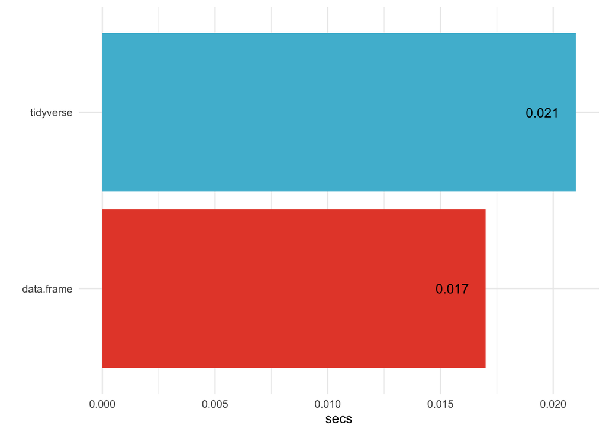

```r
subset.res <- data.frame(method = c("tidyverse", "data.frame"),
                         secs = c(round(subset.tidy.secs$toc - subset.tidy.secs$tic, digits = 3),
                                  round(subset.dt.secs$toc - subset.dt.secs$tic, digits = 3)))

ggplot(data = subset.res, aes(x = method, y = secs, fill = method)) +
  geom_bar(stat = "identity") +
  xlab("") +
  geom_text(aes(label = secs), hjust = 1.5) +
  coord_flip() +
  theme_minimal() +
  theme(legend.position = "none") +
  scale_fill_npg()
```

### Run calculations

Calculate the median number of employed who are withing the “Service occupations” category.

```r
tic()
ans.tidy <- employed %>%
  filter(major_occupation == "Service occupations") %>%
  summarize(med = median(employ_n, na.rm=TRUE))
calc.tidy.secs <- toc()
```

```
## 0.008 sec elapsed
```

```r
ans.tidy
```

```
## # A tibble: 1 x 1
##     med
##   <dbl>
## 1 31000
```

```r
tic()
ans.dt <- employed.dt[major_occupation == "Service occupations",
               .(med_n = median(employ_n, na.rm = T))]
calc.dt.secs <- toc()
```

```
## 0.007 sec elapsed
```

```r
ans.dt
```

```
##    med_n
## 1: 31000
```

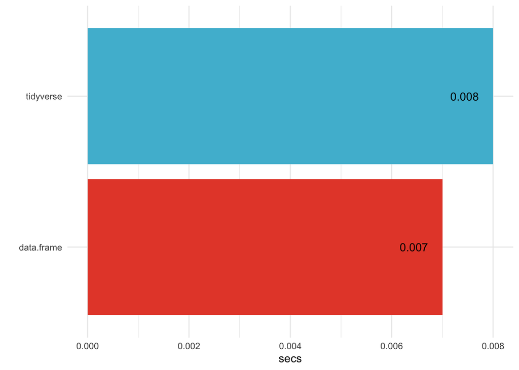

```r
calc.res <- data.frame(method = c("tidyverse", "data.frame"),
                       secs = c(round(calc.tidy.secs$toc - calc.tidy.secs$tic, digits = 3),
                                round(calc.dt.secs$toc - calc.dt.secs$tic, digits = 3)))

ggplot(data = calc.res, aes(x = method, y = secs, fill = method)) +
  geom_bar(stat = "identity") +
  xlab("") +
  geom_text(aes(label = secs), hjust = 1.5) +
  coord_flip() +
  theme_minimal() +
  theme(legend.position = "none") +
  scale_fill_npg()
```

### Run calculations by group

Now lets get the number of major occupations by industry. This will require we use the `group_by()` function in tidyverse and the `[by]` portion of data.table.

```r
tic()
employed %>%
  group_by(industry) %>%
  count(major_occupation)
```

```
## # A tibble: 130 x 3
## # Groups:   industry [26]
##    industry             major_occupation                                       n
##    <chr>                <chr>                                              <int>
##  1 Agriculture and rel… Management, professional, and related occupations     72
##  2 Agriculture and rel… Natural resources, construction, and maintenance …   108
##  3 Agriculture and rel… Production, transportation, and material moving o…    72
##  4 Agriculture and rel… Sales and office occupations                          72
##  5 Agriculture and rel… Service occupations                                   72
##  6 Asian                Management, professional, and related occupations     12
##  7 Asian                Natural resources, construction, and maintenance …    18
##  8 Asian                Production, transportation, and material moving o…    12
##  9 Asian                Sales and office occupations                          12
## 10 Asian                Service occupations                                   12
## # … with 120 more rows
```

```r
group.tidy.secs <- toc()
```

```
## 0.033 sec elapsed
```

```r
tic()
employed.dt[, .N, by = .(industry,major_occupation)]
```

```
##                                              industry
##   1:                          Agriculture and related
##   2:                          Agriculture and related
##   3:                          Agriculture and related
##   4:                          Agriculture and related
##   5:                          Agriculture and related
##  ---
## 126: Mining, quarrying, and\r\noil and gas extraction
## 127: Mining, quarrying, and\r\noil and gas extraction
## 128: Mining, quarrying, and\r\noil and gas extraction
## 129: Mining, quarrying, and\r\noil and gas extraction
## 130: Mining, quarrying, and\r\noil and gas extraction
##                                                  major_occupation   N
##   1:            Management, professional, and related occupations  72
##   2:                                          Service occupations  72
##   3:                                 Sales and office occupations  72
##   4: Natural resources, construction, and maintenance occupations 108
##   5:  Production, transportation, and material moving occupations  72
##  ---
## 126:            Management, professional, and related occupations  24
## 127:                                          Service occupations  24
## 128:                                 Sales and office occupations  24
## 129: Natural resources, construction, and maintenance occupations  36
## 130:  Production, transportation, and material moving occupations  24
```

```r
group.dt.secs <- toc()
```

```
## 0.005 sec elapsed
```

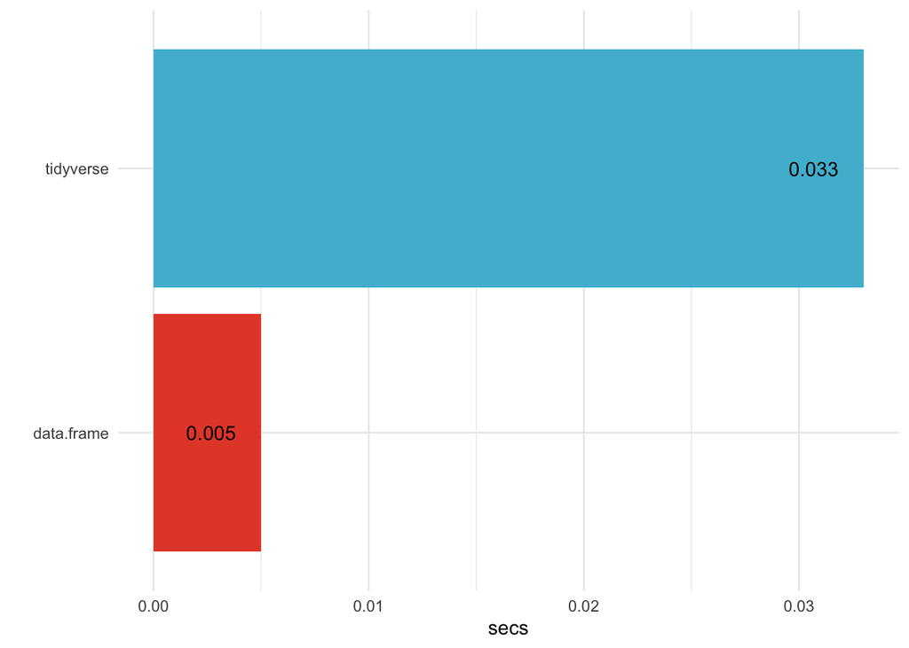

```r
calc.res <- data.frame(method = c("tidyverse", "data.frame"),
                       secs = c(round(group.tidy.secs$toc - group.tidy.secs$tic, digits = 3),
                                round(group.dt.secs$toc - group.dt.secs$tic, digits =3)))

ggplot(data = calc.res, aes(x = method, y = secs, fill = method)) +
  geom_bar(stat = "identity") +
  xlab("") +
  geom_text(aes(label = secs), hjust = 1.5) +
  coord_flip() +
  theme_minimal() +
  theme(legend.position = "none") +
  scale_fill_npg()
```

## FYI

Great reference for data.table: [link](https://cran.r-project.org/web/packages/data.table/vignettes/datatable-intro.html)

## What I learned

1. Data.table is faster than tidyverse. However, the largest gains are for subsetting and grouping data.
2. There are two ways to select columns from data tabels: Select columns the data.table way: DT[, .(colA, colB)] Select columns the data.frame way: DT[, c(“colA”, “colB”)]
3. The easiest way to think about the DT format of `DT[i, j, by]` is the following: Take DT, subset/reorder rows using i, then calculate j, grouped by by.